# 1. Description

### Course STAT467 Multivariate Analysis

#### Semester Fall 2017

#### Notebook Language R

*Notes are mostly from [Applied Multivariate Statistical Analysis (Johnson et al.)](https://www1.udel.edu/oiss/pdf/617.pdf) and [PennState 505 online course](https://onlinecourses.science.psu.edu/stat505/)

```r
options(warn=-1)
library(readr)
library(ggplot2)
```

## 2. Introduction to FA

### 2.1 Motivation behind FA

Factor Analysis is a method for modeling observed variables, and their covariance structure, in terms of a smaller number of underlying unobservable (latent) “factors.” The factors typically are viewed as broad concepts or ideas that may describe an observed phenomenon. For example, a basic desire of obtaining a certain social level might explain most of the consumption behavior. These unobserved factors are more interesting to the social scientist than the observed quantitative measurements. Factor analysis is generally an exploratory/descriptive method that requires many subjective judgments by the user. It is a widely used tool, but can be controversial because the models, methods, and subjectivity are so flexible that debates about interpretations can occur.  
Recall that in PCA interpretation of principal components is often not very clean. A particular variable may, on occasion, contribute significantly to more than one of the components. Ideally we like each variable to contribute significantly to only one component. A technique called factor rotation is employed towards that goal. Examples of fields in which factor analysis is involved include phycology, health, intelligence, sociology, and sometimes ecology and others.

## 2.2 Model in FA

In summary, the basic model is like a regression model. Each of our response variables X is to be predicted as a linear function of the unobserved common factors $f_1$ , $f_2$ through $f_m$ . Thus, our explanatory variables are $f_1$ , $f_2$ through $f_m$ . Therefore, here we are going to say that we have m unobserved factors that control the variation among our data. In general we want m << p.

$$ X_{n \ x \ p} = L_{n \ x \ m}F_{m \ x \ p}+\epsilon $$

$$ X_{1} = l_{11}f_1 + l_{12}f_2 + ... + l_{1m}f_m \\ X_{2} = l_{21}f_1 + l_{22}f_2 + ... + l_{2m}f_m \\ . \\ . \\ . \\ X_{p} = l_{p1}f_1 + l_{p2}f_2 + ... + l_{pm}f_m $$

## 2.3 Model Assumptions

**Mean**

1. The specific factors or random errors all have mean zero: $E(\epsilon_i)=0$ ; i = 1, 2, ... , p
2. The common factors, the f's, also have mean zero: $E(f_i)=0$=0; i = 1, 2, ... , m
3. A consequence of these assumptions is that the mean response of the $i^th$ trait is $\mu_i$. That is, $E(X_i)=\mu_i$

**Variance**

1. The common factors have variance one: $var(f_i)=1$; i = 1, 2, ... , m
2. The variance of specific factor $i$ is $\psi_i$: $var(\epsilon_i)=\psi_i$; i = 1, 2, ... , p Here, $\psi_i$ is called the specific variance.

**Correlation**

1. The common factors are uncorrelated with one another: $cov(f_i,f_j)=0$ for i ≠ j
2. The specific factors are uncorrelated with one another: $cov(\epsilon_i,\epsilon_j)=0$ for i ≠ j
3. The specific factors are uncorrelated with the common factors: $cov(\epsilon_i,f_j)=0$ ; i = 1, 2, ... , p; j = 1, 2, ... , m

These assumptions are necessary to uniquely estimate the parameters. An infinite number of equally well-fitting models with different values for the parameters may be obtained unless these assumptions are made.

The variance of trait i is: $\sigma^2_i=var(X_i)=\sum_{j=1}^{m}l^2_{ij}+\psi_i$

This is a derivation that can be made based on the previous assumptions.$ \sum_{j=1}^{m}l^2_{ij} $ is called the Communality for variable i. Later on we will see how this is a measure for how well the model performs for that particular variable. The larger the communality, the better the model performance for the ith variable.

The covariance between pairs of traits i and j is: $\sigma{ij}=cov(X_i,X_j)=\sum_{k=1}^{m}l_{ik}l_{jk}$
The covariance between trait i and factor j is: $cov(X_i,f_j)=l_{ij}$ $$\Sigma = L^TL + \Psi $$

$\Psi =\left[ {\begin{array}{cccc} \psi_1 & 0 & ... & 0\\ 0 & \psi_2 & ... & 0\\ ... &... & ... & ...\\ 0 & 0 & ... & \psi_p\\ \end{array} } \right] $  
$\Psi$ is diagonal matrix containing the specific variances.

It is a good idea to substract the $\mu$: $ X_{n \ x \ p} - \mu_{n \ x \ p} = L_{n \ x \ m}F_{m \ x \ p}+\epsilon $  
*There are two methods for estimating factor loadings: PCA and ML*

# 3. Examples

## 3.1 A detailed example

In a consumer-preference study, a random sample of customers were asked to rate several attributes of a new product. The responses, on a 7-point semantic differential scale, were tabulated and the attribute correlation matrix constructed. The correlation matrix is presented next:

```r
X = matrix(c(1, 0.02, 0.96, 0.42, 0.01,
             0.02, 1, 0.13, 0.71, 0.85,
             0.96, 0.13, 1, 0.5, 0.11,
             0.42, 0.71, 0.5, 1, 0.79,
             0.01, 0.85, 0.11, 0.79, 1), 5, 5)
```

Here are these five variables: Taste, Good buy for money, Flavor, Suitable for snack, Provides lots of energy. What is the minimum factors that could explain these 5 variables?  
1 and 3, and 2, 4, 5 are correlated with each other. 2 factors seems enough. Lets find eigen values:

## 3.1.1 Finding Factor Loadings

We will use the code from [Spectral Decomposition notebook](https://enesdilber.github.io/467/spectraldecomposition.html) to find eigen values and vectors. One can also use $eigen$ function in R, thats okay :(

```r
#finding eigen values
get_eigen_value = function(M){
    library(rootSolve)

    eig_calc = function(x){
        B = diag(rep(x, (dim(M)[1])))
        det((M-B))
   }
}
f = Vectorize(get_eigen_value(X)) #vectorization for uniroot function
eigenValue = uniroot.all(f, c(-10, 10))
eigenValue
```

1. 0.204492048695473

2. 1.80633384676256

3. 2.85307113756167

We have found 3 eigen values. The two greatest one is enough for our analysis. They explain $93\%$ sample variance. Since $\frac{\hat{\lambda_1}+\hat{\lambda_2}}{p} = \frac{2.85+1.81}{5} = 0.93$

```r
#finding eigenvectors
get_eigen_vector = function(lambda){

  eigen_solver = function(x){
    X%*%x-lambda*x
  }

  initial = rep(1, dim(X)[1]) #starting point for root solver

  ev = multiroot(eigen_solver, initial)$root
  ev = round(ev/sqrt(sum(ev^2)), 4) #standardization

}


eigenValue = -sort(-eigenValue)[1:2] #we sort eigenvalues from greatest to lowest
eigenVector = cbind(sapply(eigenValue, get_eigen_vector)) #we are applying eigenvector finder for every eigenvalue
```

Now we got the eigen values we could calculate factor loadings: $\hat{l_{ij}}=\sqrt{\hat{\lambda_i}}\hat{e_{ij}}$

```r
FactorLoadings = matrix(0, 5, 2)

for(i in 1:2){
    FactorLoadings[,i] = sqrt(eigenValue[i])*eigenVector[,i]
}
```

Next is communalities: $\hat{h_i}^2 = \sum_{j=1}^{2}\hat{l_{ij}}^2$

```r
Communalities = rowSums(FactorLoadings^2)
sum(Communalities)
```

4.65980151446586

Sum of communalities could be considered as explained variation. The proportion of the total variation explained by the m factors is: $$\frac{\sum_{i=1}^{p}\hat{h_{i}}}{p}=\frac{4.66}{5} = 0.93$$ This is actually what we found in eigen values. Because $\sum_{i=1}^{p}\hat{h_{i}} = \sum_{j=1}^{m}\hat{\lambda_{j}}$

And now spesific variances. This is basically residuals from $ \hat{\psi_i} = 1-\hat{h_i}^2 $ (We substract it from 1 because we used correlation matrix, rather then covariance matrix)

```r
SpesificVariance = 1 - Communalities
```

Lets create an explonatory table for factors:

```r
df = round(data.frame("FactorLoadings1" = FactorLoadings[,1],
                      "FactorLoadings2" = FactorLoadings[,2],
                      "Communalities" = Communalities,
                      "SpesificVariance" = SpesificVariance), 3)
row.names(df) = c("Taste", "Good buy for money", "Flavor", "Suitable for snack", "Provides lots of energy")
df
```

|  | FactorLoadings1 | FactorLoadings2 | Communalities | SpesificVariance |
| --- | --- | --- | --- | --- |
| Taste | 0.560 | -0.816 | 0.980 | 0.020 |
| Good buy for money | 0.777 | 0.524 | 0.879 | 0.121 |
| Flavor | 0.645 | -0.748 | 0.976 | 0.024 |
| Suitable for snack | 0.939 | 0.105 | 0.893 | 0.107 |
| Provides lots of energy | 0.798 | 0.543 | 0.932 | 0.068 |

Communalities (.98, .88, .98, .89, .93) indicate that the two factors account for a large percentage of the sample variance of each variable.

## 3.1.2 Rotation

Here is the plot of factor loading 1 vs factor loading 2. These plot shows the correlation between factor and variables.

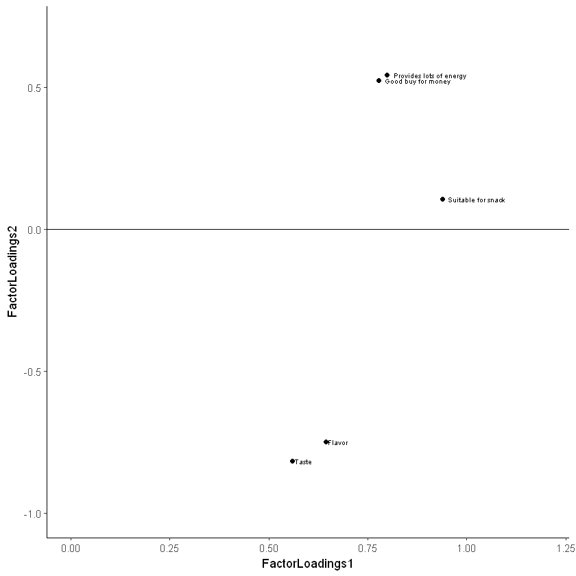

```r
ggplot(df, aes(x=FactorLoadings1, y=FactorLoadings2)) +
    geom_point() + theme_classic()+ ylim(c(-1, 0.7)) + xlim(c(0, 1.2))+
    geom_text(label=rownames(df), vjust = 0.5, hjust = -0.1, size = 2.2) + geom_hline(aes(yintercept=0))
```

```r
calc_Lstar = function(L, theta){
     T = matrix(c(cos(theta), -sin(theta),
                 sin(theta), cos(theta)),2,2, byrow = T)

    return(L%*%T)
}


opt_func = function(k, L){
    theta = k*pi

    Lstar = calc_Lstar(L, theta)

    Omega = sum(apply(Lstar, 1, var))

    return(Omega)

}

k_seq = seq(0, 2, length = 10000)
```

```r
Omegas = sapply(k_seq, function(x) opt_func(x, FactorLoadings))
```

```r
optk = k_seq[which.max(Omegas)]
optk
```

0.25002500250025

We could say optimum $\theta$ is $0.25\pi$. So we are going to rotate the axis $45^{\circ}$ counterclockwise.

```r
x_axis_slope = tan((pi/2) - optk*pi)
y_axis_slope = -tan(optk*pi)
```

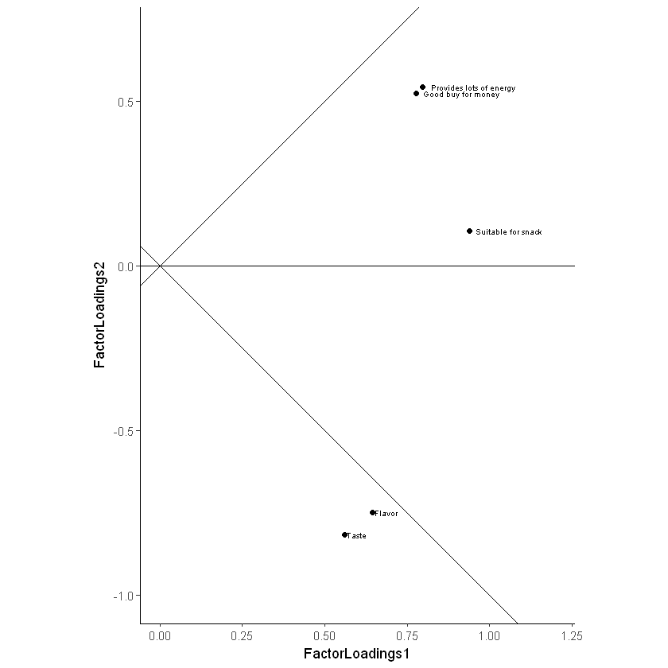

```r
ggplot(df, aes(x=FactorLoadings1, y=FactorLoadings2)) +
    geom_point() + theme_classic()+ ylim(c(-1, 0.7)) + xlim(c(0, 1.2))+
    geom_text(label=rownames(df), vjust = 0.5, hjust = -0.1, size = 2.2) + geom_hline(aes(yintercept=0))+
    geom_abline(intercept = 0, slope = x_axis_slope) + geom_abline(intercept = 0, slope = y_axis_slope) + coord_fixed()
```

Lets again create explonatary tabkle of factors with rotated factor loadings.

```r
RotatedLoadings = calc_Lstar(FactorLoadings, optk*pi)

df = round(data.frame("FactorLoadings1" = FactorLoadings[,1],
                      "FactorLoadings2" = FactorLoadings[,2],
                      "RotatedFactors1" = RotatedLoadings[,1],
                      "RotatedFactors2" = RotatedLoadings[,2],
                      "Communalities" = Communalities,
                      "SpesificVariance" = SpesificVariance), 3)
row.names(df) = c("Taste", "Good buy for money", "Flavor", "Suitable for snack", "Provides lots of energy")
df
```

|  | FactorLoadings1 | FactorLoadings2 | RotatedFactors1 | RotatedFactors2 | Communalities | SpesificVariance |
| --- | --- | --- | --- | --- | --- | --- |
| Taste | 0.560 | -0.816 | -0.181 | -0.973 | 0.980 | 0.020 |
| Good buy for money | 0.777 | 0.524 | 0.920 | -0.179 | 0.879 | 0.121 |
| Flavor | 0.645 | -0.748 | -0.073 | -0.985 | 0.976 | 0.024 |
| Suitable for snack | 0.939 | 0.105 | 0.738 | -0.590 | 0.893 | 0.107 |
| Provides lots of energy | 0.798 | 0.543 | 0.949 | -0.180 | 0.932 | 0.068 |

We could now interpret rotated factors. It is clear that r-Factor 2 is the factor that is behind Taste and Flavour and r-Factor 1 is behind Good buy for money and Provides lots of energy. Suitable for snack is more explained by r-Factor 1 but we cannot say it is belong to a spesific factor.

## 3.2 An applied example

```r
data = read_csv("https://raw.githubusercontent.com/enesdilber/467/master/fa_data.csv", col_types = cols(X1 = col_skip()))
data = log10(data[,1:9])
head(data)
```

| Climate | HousingCost | HlthCare | Crime | Transp | Educ | Arts | Recreat | Econ |
| --- | --- | --- | --- | --- | --- | --- | --- | --- |
| 2.716838 | 3.792392 | 2.374748 | 2.965202 | 3.605413 | 3.440437 | 2.998259 | 3.147676 | 3.882695 |
| 2.759668 | 3.910518 | 3.219060 | 2.947434 | 3.688687 | 3.387034 | 3.745387 | 3.420286 | 3.638489 |
| 2.670246 | 3.865637 | 2.790988 | 2.986772 | 3.403292 | 3.408240 | 2.374748 | 2.933993 | 3.720159 |
| 2.677607 | 3.898067 | 3.155640 | 2.785330 | 3.837778 | 3.531351 | 3.667920 | 3.208710 | 3.768194 |
| 2.818885 | 3.923917 | 3.267875 | 3.171141 | 3.816771 | 3.480869 | 3.652826 | 3.416973 | 3.757927 |
| 2.716003 | 3.764848 | 2.806180 | 2.861534 | 3.388101 | 3.473049 | 2.523746 | 3.007748 | 3.720490 |

Our objective here is to describe the inter-relationships among the variables. Here are 9 variables:  
To deciding the number of factor loadings $m$, One can take help from PC's

```r
X.pca = prcomp(data, center = FALSE, scale = FALSE)
round(X.pca$rotation,3) #Here is our principal component
```

|  | PC1 | PC2 | PC3 | PC4 | PC5 | PC6 | PC7 | PC8 | PC9 |
| --- | --- | --- | --- | --- | --- | --- | --- | --- | --- |
| Climate | -0.272 | 0.160 | -0.008 | 0.153 | -0.128 | 0.490 | 0.726 | 0.184 | 0.244 |
| HousingCost | -0.391 | 0.175 | -0.012 | -0.181 | -0.208 | 0.276 | -0.117 | -0.791 | -0.154 |
| HlthCare | -0.297 | -0.284 | -0.867 | -0.009 | 0.274 | -0.022 | -0.016 | 0.009 | 0.062 |
| Crime | -0.296 | 0.112 | 0.195 | 0.775 | 0.454 | -0.137 | -0.049 | -0.147 | -0.113 |
| Transp | -0.360 | 0.087 | 0.039 | -0.119 | -0.259 | -0.801 | 0.331 | -0.067 | 0.156 |
| Educ | -0.345 | 0.205 | -0.076 | -0.017 | -0.251 | 0.032 | -0.105 | 0.458 | -0.740 |
| Arts | -0.323 | -0.857 | 0.327 | 0.053 | -0.195 | 0.097 | -0.046 | 0.048 | -0.016 |
| Recreat | -0.323 | 0.061 | 0.309 | -0.569 | 0.672 | 0.042 | 0.047 | 0.131 | -0.003 |
| Econ | -0.374 | 0.251 | 0.035 | 0.049 | -0.198 | 0.103 | -0.576 | 0.290 | 0.572 |

```r
summary(X.pca)
```

```
Importance of components:
                           PC1     PC2     PC3     PC4     PC5     PC6     PC7
Standard deviation     10.0005 0.49694 0.22573 0.15162 0.13634 0.12891 0.10563
Proportion of Variance  0.9963 0.00246 0.00051 0.00023 0.00019 0.00017 0.00011
Cumulative Proportion   0.9963 0.99873 0.99924 0.99947 0.99965 0.99982 0.99993
                           PC8     PC9
Standard deviation     0.06770 0.05225
Proportion of Variance 0.00005 0.00003
Cumulative Proportion  0.99997 1.00000
```

```r
X.fa = factanal(x = data, factors = 3, rotation = "varimax")
```

```r
X.fa
```

```
Call:
factanal(x = data, factors = 3, rotation = "varimax")

Uniquenesses:
    Climate HousingCost    HlthCare       Crime      Transp        Educ
      0.005       0.586       0.185       0.784       0.617       0.735
       Arts     Recreat        Econ
      0.255       0.462       0.886

Loadings:
            Factor1 Factor2 Factor3
Climate                      0.994
HousingCost  0.360   0.482   0.229
HlthCare     0.884   0.164
Crime        0.115   0.400   0.205
Transp       0.414   0.460
Educ         0.511
Arts         0.655   0.552   0.102
Recreat      0.148   0.714
Econ                 0.318  -0.114

               Factor1 Factor2 Factor3
SS loadings      1.814   1.551   1.120
Proportion Var   0.202   0.172   0.124
Cumulative Var   0.202   0.374   0.498

Test of the hypothesis that 3 factors are sufficient.
The chi square statistic is 92.74 on 12 degrees of freedom.
The p-value is 1.45e-14
```